# Analysis of Amazon Customer Reviews

Feiyun Yan, Yuchen Dou, Bingyan Liang, Shuwei Liu

2022-12-16

**Introduction**

Amazon is one of the largest online shopping websites in the world, and millions of product reviews are posted on this well-known site from users in each continent since 1995. In this way, it is a precious data resource for us to learn about business cycles and financial behaviors. In light of it, we would like to explore a question that has always been in our mind: Are “good products” becoming increasingly popular as time grows?

**Data Description**

The dataset that we utilize is collected and provided by Amazon. Focusing on products related to entertainment, we have a dataset with a size of 11.5GB. Although there are 15 columns in total, considering their relativeness to our topic, we cleaned the dataset and concentrated on six of them. Below is a detailed description of the variables covered in our study.

*product-parent: An identifier used to identify each product.

*product_title: Title of the product.

*product_category: Category of a product.

*star_rating: The rating given by the reviewer.

*verified_purchase: If the reviewer is verified to have purchased the product.

*review_date: The date of the review.

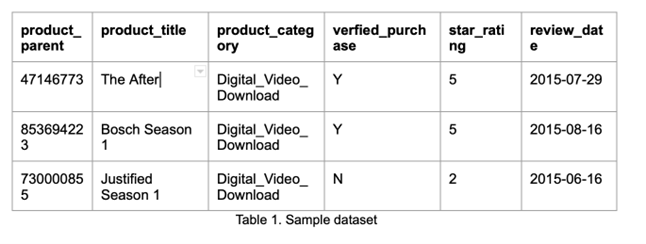

**Statistical Computation**

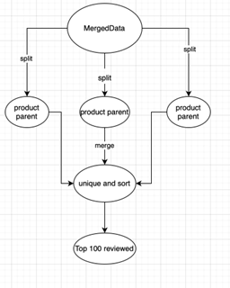

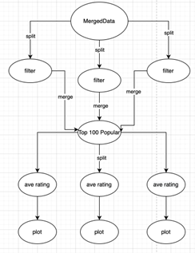

**Analysis**

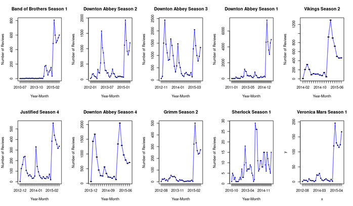

Figure 1. Number of reviews of Top 10 products by month

Those ten plots above depict the change in the number of reviews by month of the ten products with the highest average rating among the top 100 reviewed ones. It is easy to notice that the number of reviews surged whenever a new episode or season is published. Another interesting phenomenon we found is that there are 4 seasons of the Downton Abbey TV series among the top 10 products.

[figure not shown]

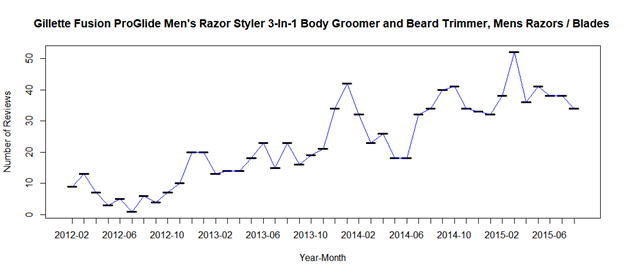

Figure 3. The number of reviews of Men’s Body Groomer

Despite most of the popular reviewed products being digital videos, it is also very intriguing to focus on products from other categories. Here we have the monthly reviewed frequency of a Male’s body groomer shown in the graph above. With a huge number of reviews (most are removed as being not verified purchases), and a decent average star rating, the body groomer, as a daily-use product, has an overall increase in popularity.

**Conclusion**

We found that “good products” from the digital video category do not always become more popular as time passes. Instead, reviews on them proliferated during people’s holidays or whenever a new season is dropped. However, for a daily-use product, when it is widely recognized, an increasing number of purchasing and reviews can be expected. In the future, we can improve our project with a more recent larger dataset containing more categories.